# FinalExam-2802420731-Kaelyn Renata Halim

Kaelyn Renata Halim

2025-06-19

[Video Explanation](https://drive.google.com/file/d/1vg9XoWtm_BrK9_9o1y9aNY78rtI42Qaf/view?usp=sharing)

### 1 Case Studies

#### 1.1 Data Quality Assessment and Preprocessing

**A. Identify data quality issues**

Import the dataset.

```
##   X age        job marital           education default housing loan   contact
## 1 0  40 technician  single   university.degree      no      no   no  cellular
## 2 1  45 unemployed married professional.course      no     yes  yes  cellular
## 3 2  33     admin.  single   university.degree      no     yes   no  cellular
## 4 3  29 technician married   university.degree      no      no   no telephone
## 5 4  55    retired married            basic.4y      no      no   no  cellular
## 6 5  29     admin.  single         high.school      no     yes   no  cellular
##   month day_of_week duration campaign pdays previous    poutcome   y
## 1   nov         mon      130        1     7        2     failure yes
## 2   aug         fri       98        5   999        0 nonexistent  no
## 3   jul         mon      182        1   999        0 nonexistent  no
## 4   may         fri      410        3   999        0 nonexistent  no
## 5   jun         tue      130        2   999        0 nonexistent  no
## 6   may         thu      566        2   999        0 nonexistent yes
```

Data Summary

```
##        X             age            job              marital
##  Min.   :   0   Min.   :18.00   Length:8238        Length:8238
##  1st Qu.:2059   1st Qu.:32.00   Class :character   Class :character
##  Median :4118   Median :38.00   Mode  :character   Mode  :character
##  Mean   :4118   Mean   :40.25
##  3rd Qu.:6178   3rd Qu.:47.00
##  Max.   :8237   Max.   :91.00
##
##   education           default            housing              loan
##  Length:8238        Length:8238        Length:8238        Length:8238
##  Class :character   Class :character   Class :character   Class :character
##  Mode  :character   Mode  :character   Mode  :character   Mode  :character
##
##
##
##
##    contact             month           day_of_week           duration
##  Length:8238        Length:8238        Length:8238        Min.   :   1.0
##  Class :character   Class :character   Class :character   1st Qu.: 102.0
##  Mode  :character   Mode  :character   Mode  :character   Median : 175.0
##                                                           Mean   : 254.3
##                                                           3rd Qu.: 314.0
##                                                           Max.   :3785.0
##                                                           NA's   :9
##     campaign          pdays          previous       poutcome
##  Min.   : 1.000   Min.   :  0.0   Min.   :0.000   Length:8238
##  1st Qu.: 1.000   1st Qu.:999.0   1st Qu.:0.000   Class :character
##  Median : 2.000   Median :999.0   Median :0.000   Mode  :character
##  Mean   : 2.566   Mean   :959.2   Mean   :0.184
##  3rd Qu.: 3.000   3rd Qu.:999.0   3rd Qu.:0.000
##  Max.   :56.000   Max.   :999.0   Max.   :7.000
##
##       y
##  Length:8238
##  Class :character
##  Mode  :character
##
##
##
##
```

Assign proper data types to each variable. Change the **job**, **marital**, **education**, **default**, **housing**, **loan**, **contact**, **month**, **day_of_week**, **poutcome**, and **y** variables from character to factor.

```
##        X             age                 job           marital
##  Min.   :   0   Min.   :18.00   admin.     :2141   divorced: 942
##  1st Qu.:2059   1st Qu.:32.00   blue-collar:1841   married :5074
##  Median :4118   Median :38.00   technician :1333   single  :2205
##  Mean   :4118   Mean   :40.25   services   : 791   unknown :  17
##  3rd Qu.:6178   3rd Qu.:47.00   management : 560
##  Max.   :8237   Max.   :91.00   retired    : 352
##                                 (Other)    :1220
##                education       default        housing          loan
##  university.degree  :2395   no     :6486   no     :3726   no     :6721
##  high.school        :1905   unknown:1752   unknown: 196   unknown: 196
##  basic.9y           :1220                  yes    :4316   yes    :1321
##  professional.course:1057
##  basic.4y           : 836
##  basic.6y           : 461
##  (Other)            : 364
##       contact         month      day_of_week    duration         campaign
##  cellular :5238   may    :2762   fri:1596    Min.   :   1.0   Min.   : 1.000
##  telephone:3000   jul    :1375   mon:1762    1st Qu.: 102.0   1st Qu.: 1.000
##                   aug    :1343   thu:1714    Median : 175.0   Median : 2.000
##                   jun    :1046   tue:1578    Mean   : 254.3   Mean   : 2.566
##                   nov    : 824   wed:1588    3rd Qu.: 314.0   3rd Qu.: 3.000
##                   apr    : 483               Max.   :3785.0   Max.   :56.000
##                   (Other): 405               NA's   :9
##      pdays          previous            poutcome      y
##  Min.   :  0.0   Min.   :0.000   failure    : 876   no :7348
##  1st Qu.:999.0   1st Qu.:0.000   nonexistent:7070   yes: 890
##  Median :999.0   Median :0.000   success    : 292
##  Mean   :959.2   Mean   :0.184
##  3rd Qu.:999.0   3rd Qu.:0.000
##  Max.   :999.0   Max.   :7.000
##
```

*Missing values*

Check levels for **job**, **education**, and **month** variables.

```
##  [1] ""              "admin."        "blue-collar"   "entrepreneur"
##  [5] "housemaid"     "management"    "retired"       "self-employed"
##  [9] "services"      "student"       "technician"    "unemployed"
## [13] "unknown"
```

```
## [1] "basic.4y"            "basic.6y"            "basic.9y"
## [4] "high.school"         "illiterate"          "professional.course"
## [7] "university.degree"   "unknown"
```

```
##  [1] "apr" "aug" "dec" "jul" "jun" "mar" "may" "nov" "oct" "sep"
```

Check for outliers in the **duration** variable with a box plot to manage the NA data.

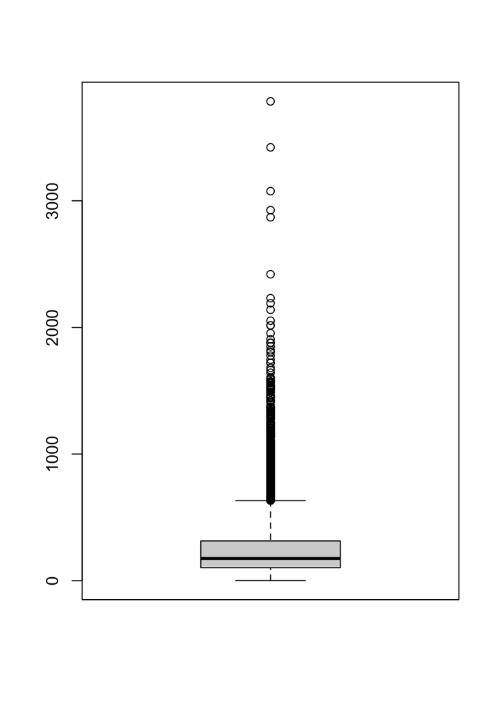

*Duplicate records*

Check for duplicates.

```
## integer(0)
```

There are no duplicate rows in this dataset.

*Inconsistent or unknown categories*

Check levels of categorical variables that have many levels (**job**, **education**, **month**).

```
##  [1] ""              "admin."        "blue-collar"   "entrepreneur"
##  [5] "housemaid"     "management"    "retired"       "self-employed"
##  [9] "services"      "student"       "technician"    "unemployed"
## [13] "unknown"
```

```
##
##                      admin.   blue-collar  entrepreneur     housemaid
##             9          2141          1841           298           227
##    management       retired self-employed      services       student
##           560           352           253           791           170
##    technician    unemployed       unknown
##          1333           192            71
```

```
## [1] "basic.4y"            "basic.6y"            "basic.9y"
## [4] "high.school"         "illiterate"          "professional.course"
## [7] "university.degree"   "unknown"
```

```
##
##            basic.4y            basic.6y            basic.9y         high.school
##                 836                 461                1220                1905
##          illiterate professional.course   university.degree             unknown
##                   1                1057                2395                 363
```

```
##  [1] "apr" "aug" "dec" "jul" "jun" "mar" "may" "nov" "oct" "sep"
```

*Noisy or irrelevant values*

Check for outliers in the **age**, **duration**, **campaign**, **pdays**, and **previous** variables with box plots.

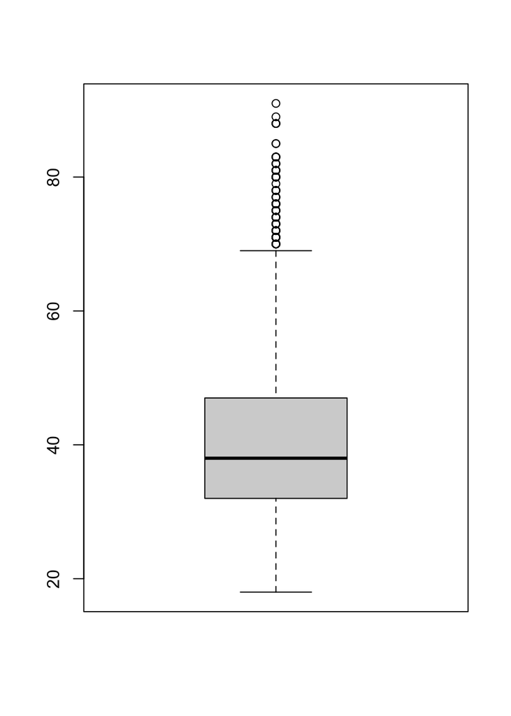

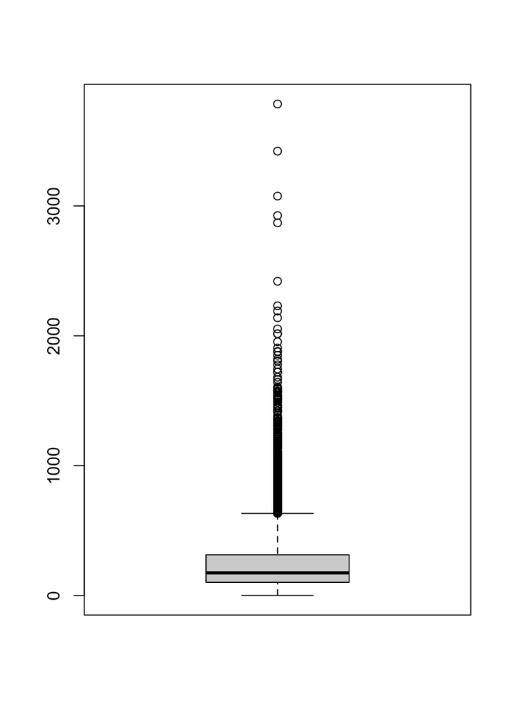

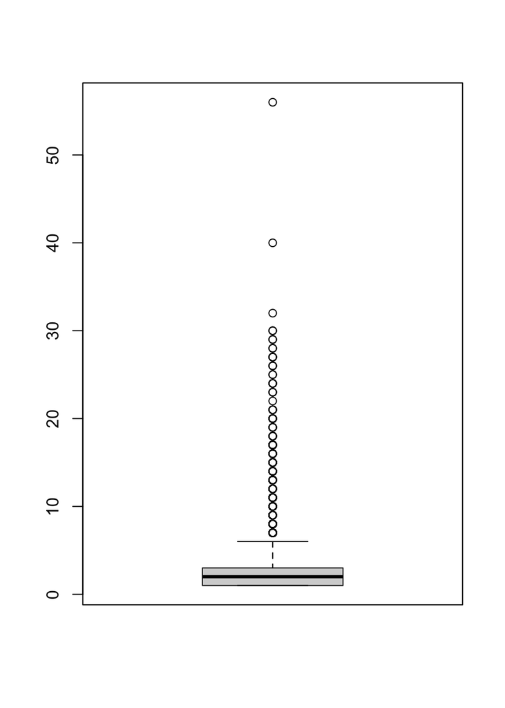

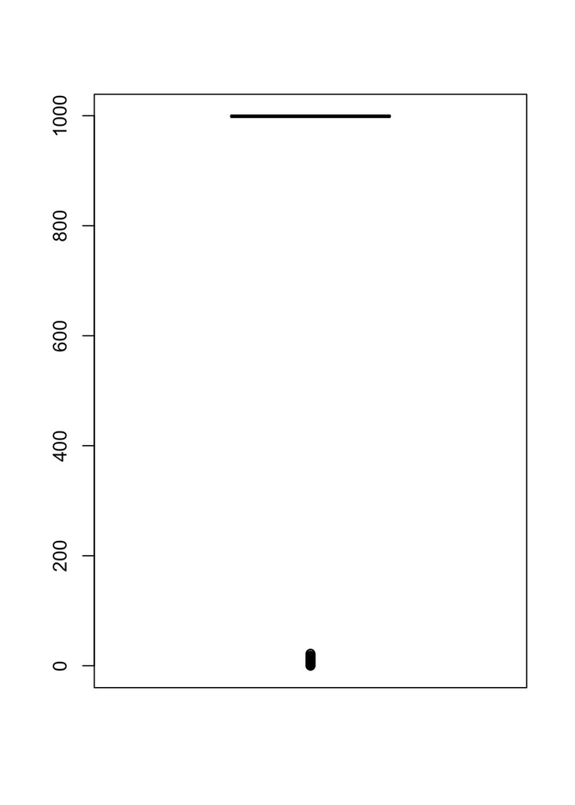

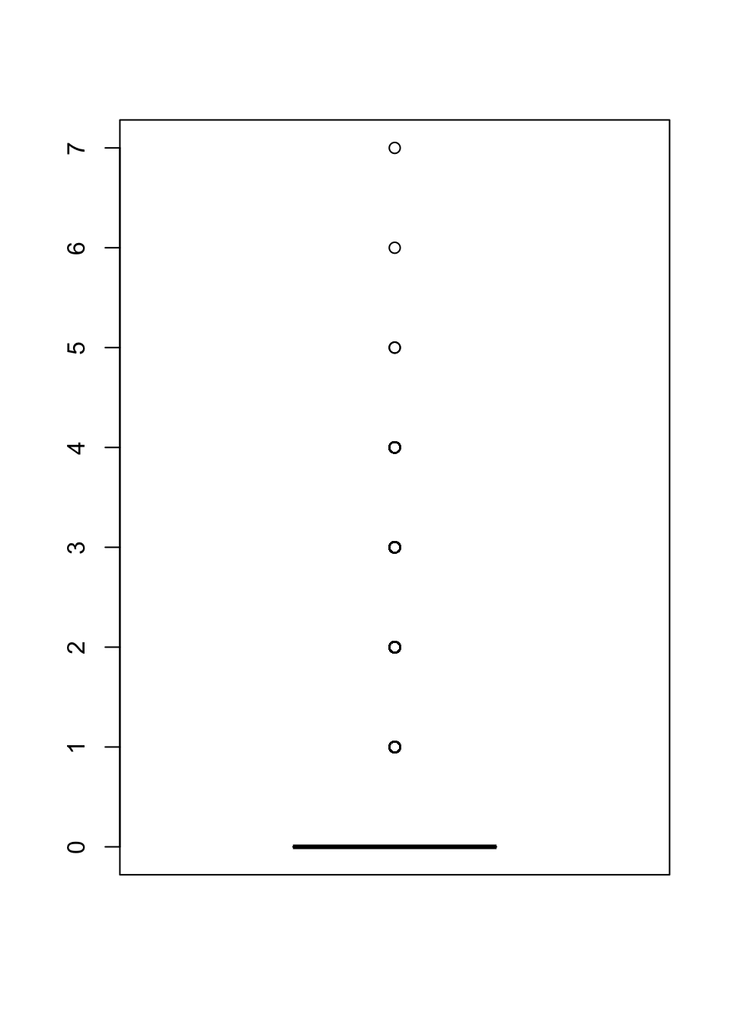

**B. Handle the issues you identified**

Remove rows that have missing values the **age**, **job**, **duration**, **campaign**, **pdays**, and **previous** variables. For categorical variables like **job**, rows with missing values are removed because imputing them with any job level there is would alter the authenticity of the responses.

```
## [1] 8238
```

```
## [1] 8229
```

```
##        X             age                 job           marital
##  Min.   :   0   Min.   :18.00   admin.     :2141   divorced: 940
##  1st Qu.:2060   1st Qu.:32.00   blue-collar:1841   married :5068
##  Median :4120   Median :38.00   technician :1333   single  :2204
##  Mean   :4119   Mean   :40.25   services   : 791   unknown :  17
##  3rd Qu.:6179   3rd Qu.:47.00   management : 560
##  Max.   :8237   Max.   :91.00   retired    : 352
##                                 (Other)    :1211
##                education       default        housing          loan
##  university.degree  :2391   no     :6479   no     :3722   no     :6713
##  high.school        :1903   unknown:1750   unknown: 196   unknown: 196
##  basic.9y           :1219                  yes    :4311   yes    :1320
##  professional.course:1056
##  basic.4y           : 836
##  basic.6y           : 460
##  (Other)            : 364
##       contact         month      day_of_week    duration         campaign
##  cellular :5234   may    :2760   fri:1594    Min.   :   1.0   Min.   : 1.000
##  telephone:2995   jul    :1372   mon:1762    1st Qu.: 101.8   1st Qu.: 1.000
##                   aug    :1342   thu:1713    Median : 175.0   Median : 2.000
##                   jun    :1043   tue:1575    Mean   : 254.4   Mean   : 2.565
##                   nov    : 824   wed:1585    3rd Qu.: 314.0   3rd Qu.: 3.000
##                   apr    : 483               Max.   :3785.0   Max.   :56.000
##                   (Other): 405               NA's   :9
##      pdays          previous             poutcome      y
##  Min.   :  0.0   Min.   :0.0000   failure    : 876   no :7339
##  1st Qu.:999.0   1st Qu.:0.0000   nonexistent:7061   yes: 890
##  Median :999.0   Median :0.0000   success    : 292
##  Mean   :959.2   Mean   :0.1842
##  3rd Qu.:999.0   3rd Qu.:0.0000
##  Max.   :999.0   Max.   :7.0000
##
```

Because there are outliers in the **duration** variable, the NA data will be replaced by the median because the median is not affected by the values in the data and the skewness of the data.

```
## [1] 175
```

```
##        X             age                 job           marital
##  Min.   :   0   Min.   :18.00   admin.     :2141   divorced: 940
##  1st Qu.:2060   1st Qu.:32.00   blue-collar:1841   married :5068
##  Median :4120   Median :38.00   technician :1333   single  :2204
##  Mean   :4119   Mean   :40.25   services   : 791   unknown :  17
##  3rd Qu.:6179   3rd Qu.:47.00   management : 560
##  Max.   :8237   Max.   :91.00   retired    : 352
##                                 (Other)    :1211
##                education       default        housing          loan
##  university.degree  :2391   no     :6479   no     :3722   no     :6713
##  high.school        :1903   unknown:1750   unknown: 196   unknown: 196
##  basic.9y           :1219                  yes    :4311   yes    :1320
##  professional.course:1056
##  basic.4y           : 836
##  basic.6y           : 460
##  (Other)            : 364
##       contact         month      day_of_week    duration         campaign
##  cellular :5234   may    :2760   fri:1594    Min.   :   1.0   Min.   : 1.000
##  telephone:2995   jul    :1372   mon:1762    1st Qu.: 102.0   1st Qu.: 1.000
##                   aug    :1342   thu:1713    Median : 175.0   Median : 2.000
##                   jun    :1043   tue:1575    Mean   : 254.4   Mean   : 2.565
##                   nov    : 824   wed:1585    3rd Qu.: 314.0   3rd Qu.: 3.000
##                   apr    : 483               Max.   :3785.0   Max.   :56.000
##                   (Other): 405
##      pdays          previous             poutcome      y
##  Min.   :  0.0   Min.   :0.0000   failure    : 876   no :7339
##  1st Qu.:999.0   1st Qu.:0.0000   nonexistent:7061   yes: 890
##  Median :999.0   Median :0.0000   success    : 292
##  Mean   :959.2   Mean   :0.1842
##  3rd Qu.:999.0   3rd Qu.:0.0000
##  Max.   :999.0   Max.   :7.0000
##
```

I’ll drop unknown rows in the **job** and **marital** variables because they each make up less than 1% of the total responses. As for the unknowns in the **education** variable, I’ll convert them to NA first, and then impute them with “university.degree” as it’s the most common level. For unknowns in the **default**, **housing**, and **loan** variables, I’ll keep them as valid categories because they might be meaningful, and I don’t want to lose rows unnecessarily.

```
## [1] 8229
```

```
##        X             age                job           marital
##  Min.   :   0   Min.   :18.0   admin.     :2139   divorced: 935
##  1st Qu.:2058   1st Qu.:32.0   blue-collar:1839   married :5020
##  Median :4117   Median :38.0   technician :1327   single  :2190
##  Mean   :4118   Mean   :40.2   services   : 790   unknown :   0
##  3rd Qu.:6183   3rd Qu.:47.0   management : 560
##  Max.   :8237   Max.   :91.0   retired    : 352
##                                (Other)    :1138
##                education       default        housing          loan
##  university.degree  :2712   no     :6429   no     :3688   no     :6641
##  high.school        :1895   unknown:1716   unknown: 195   unknown: 195
##  basic.9y           :1211                  yes    :4262   yes    :1309
##  professional.course:1054
##  basic.4y           : 814
##  basic.6y           : 458
##  (Other)            :   1
##       contact         month      day_of_week    duration         campaign
##  cellular :5185   may    :2726   fri:1582    Min.   :   1.0   Min.   : 1.000
##  telephone:2960   jul    :1361   mon:1740    1st Qu.: 102.0   1st Qu.: 1.000
##                   aug    :1328   thu:1697    Median : 175.0   Median : 2.000
##                   jun    :1031   tue:1559    Mean   : 254.5   Mean   : 2.562
##                   nov    : 819   wed:1567    3rd Qu.: 314.0   3rd Qu.: 3.000
##                   apr    : 480               Max.   :3785.0   Max.   :56.000
##                   (Other): 400
##      pdays          previous             poutcome      y
##  Min.   :  0.0   Min.   :0.0000   failure    : 869   no :7269
##  1st Qu.:999.0   1st Qu.:0.0000   nonexistent:6987   yes: 876
##  Median :999.0   Median :0.0000   success    : 289
##  Mean   :959.1   Mean   :0.1843
##  3rd Qu.:999.0   3rd Qu.:0.0000
##  Max.   :999.0   Max.   :7.0000
##
```

For outliers in the **age**, **duration**, and **previous** variables, I’ll keep them because they’re valid. For outliers in campaign, I’ll take note of some that are over 10 as extreme in case of unusually high contact counts. For the 999s in the pdays variable, I’ll convert them to a separate category called “not_contacted”.

```
##
## FALSE  TRUE
##  7972   173
```

```
##
##     FALSE      TRUE
## 97.875998  2.124002
```

```
##
##     contacted not_contacted
##           327          7818
```

```
##
##     contacted not_contacted
##      4.014733     95.985267
```

*Create a cleaned version of the dataset called clean_data*

```
##        X             age                job           marital
##  Min.   :   0   Min.   :18.0   admin.     :2139   divorced: 935
##  1st Qu.:2058   1st Qu.:32.0   blue-collar:1839   married :5020
##  Median :4117   Median :38.0   technician :1327   single  :2190
##  Mean   :4118   Mean   :40.2   services   : 790   unknown :   0
##  3rd Qu.:6183   3rd Qu.:47.0   management : 560
##  Max.   :8237   Max.   :91.0   retired    : 352
##                                (Other)    :1138
##                education       default        housing          loan
##  university.degree  :2712   no     :6429   no     :3688   no     :6641
##  high.school        :1895   unknown:1716   unknown: 195   unknown: 195
##  basic.9y           :1211                  yes    :4262   yes    :1309
##  professional.course:1054
##  basic.4y           : 814
##  basic.6y           : 458
##  (Other)            :   1
##       contact         month      day_of_week    duration         campaign
##  cellular :5185   may    :2726   fri:1582    Min.   :   1.0   Min.   : 1.000
##  telephone:2960   jul    :1361   mon:1740    1st Qu.: 102.0   1st Qu.: 1.000
##                   aug    :1328   thu:1697    Median : 175.0   Median : 2.000
##                   jun    :1031   tue:1559    Mean   : 254.5   Mean   : 2.562
##                   nov    : 819   wed:1567    3rd Qu.: 314.0   3rd Qu.: 3.000
##                   apr    : 480               Max.   :3785.0   Max.   :56.000
##                   (Other): 400
##      pdays          previous             poutcome      y        campaign_flag
##  Min.   :  0.0   Min.   :0.0000   failure    : 869   no :7269   Mode :logical
##  1st Qu.:999.0   1st Qu.:0.0000   nonexistent:6987   yes: 876   FALSE:7972
##  Median :999.0   Median :0.0000   success    : 289              TRUE :173
##  Mean   :959.1   Mean   :0.1843
##  3rd Qu.:999.0   3rd Qu.:0.0000
##  Max.   :999.0   Max.   :7.0000
##
##  pdays_status
##  Length:8145
##  Class :character
##  Mode  :character
##
##
##
##
```

Make the **pdays_status** variable into factor data type.

```
##        X             age                job           marital
##  Min.   :   0   Min.   :18.0   admin.     :2139   divorced: 935
##  1st Qu.:2058   1st Qu.:32.0   blue-collar:1839   married :5020
##  Median :4117   Median :38.0   technician :1327   single  :2190
##  Mean   :4118   Mean   :40.2   services   : 790   unknown :   0
##  3rd Qu.:6183   3rd Qu.:47.0   management : 560
##  Max.   :8237   Max.   :91.0   retired    : 352
##                                (Other)    :1138
##                education       default        housing          loan
##  university.degree  :2712   no     :6429   no     :3688   no     :6641
##  high.school        :1895   unknown:1716   unknown: 195   unknown: 195
##  basic.9y           :1211                  yes    :4262   yes    :1309
##  professional.course:1054
##  basic.4y           : 814
##  basic.6y           : 458
##  (Other)            :   1
##       contact         month      day_of_week    duration         campaign
##  cellular :5185   may    :2726   fri:1582    Min.   :   1.0   Min.   : 1.000
##  telephone:2960   jul    :1361   mon:1740    1st Qu.: 102.0   1st Qu.: 1.000
##                   aug    :1328   thu:1697    Median : 175.0   Median : 2.000
##                   jun    :1031   tue:1559    Mean   : 254.5   Mean   : 2.562
##                   nov    : 819   wed:1567    3rd Qu.: 314.0   3rd Qu.: 3.000
##                   apr    : 480               Max.   :3785.0   Max.   :56.000
##                   (Other): 400
##      pdays          previous             poutcome      y        campaign_flag
##  Min.   :  0.0   Min.   :0.0000   failure    : 869   no :7269   Mode :logical
##  1st Qu.:999.0   1st Qu.:0.0000   nonexistent:6987   yes: 876   FALSE:7972
##  Median :999.0   Median :0.0000   success    : 289              TRUE :173
##  Mean   :959.1   Mean   :0.1843
##  3rd Qu.:999.0   3rd Qu.:0.0000
##  Max.   :999.0   Max.   :7.0000
##
##         pdays_status
##  contacted    : 327
##  not_contacted:7818
##
##
##
##
##
```

Drop **X** variable because it’s just the row index.

Make a new variable “**pdays_num**” to look at the non-999 values while keeping the numerical data type.

Review imputation of **education** variable if it’s by mode or model-based, to check if there are still unknown values.

```
##
##            basic.4y            basic.6y            basic.9y         high.school
##                 814                 458                1211                1895
##          illiterate professional.course   university.degree             unknown
##                   1                1054                2712                   0
```

There are no more unknown values in the **education** variable.

Reorder factor levels in the **education** variable.

```
##
##          illiterate            basic.4y            basic.6y            basic.9y
##                   1                 814                 458                1211
##         high.school professional.course   university.degree
##                1895                1054                2712
```

Final summary of the cleaned dataset.

```
##       age                job           marital                   education
##  Min.   :18.0   admin.     :2139   divorced: 935   illiterate         :   1
##  1st Qu.:32.0   blue-collar:1839   married :5020   basic.4y           : 814
##  Median :38.0   technician :1327   single  :2190   basic.6y           : 458
##  Mean   :40.2   services   : 790   unknown :   0   basic.9y           :1211
##  3rd Qu.:47.0   management : 560                   high.school        :1895
##  Max.   :91.0   retired    : 352                   professional.course:1054
##                 (Other)    :1138                   university.degree  :2712
##     default        housing          loan           contact         month
##  no     :6429   no     :3688   no     :6641   cellular :5185   may    :2726
##  unknown:1716   unknown: 195   unknown: 195   telephone:2960   jul    :1361
##                 yes    :4262   yes    :1309                    aug    :1328
##                                                                jun    :1031
##                                                                nov    : 819
##                                                                apr    : 480
##                                                                (Other): 400
##  day_of_week    duration         campaign          pdays          previous
##  fri:1582    Min.   :   1.0   Min.   : 1.000   Min.   :  0.0   Min.   :0.0000
##  mon:1740    1st Qu.: 102.0   1st Qu.: 1.000   1st Qu.:999.0   1st Qu.:0.0000
##  thu:1697    Median : 175.0   Median : 2.000   Median :999.0   Median :0.0000
##  tue:1559    Mean   : 254.5   Mean   : 2.562   Mean   :959.1   Mean   :0.1843
##  wed:1567    3rd Qu.: 314.0   3rd Qu.: 3.000   3rd Qu.:999.0   3rd Qu.:0.0000
##              Max.   :3785.0   Max.   :56.000   Max.   :999.0   Max.   :7.0000
##
##         poutcome      y        campaign_flag          pdays_status
##  failure    : 869   no :7269   Mode :logical   contacted    : 327
##  nonexistent:6987   yes: 876   FALSE:7972      not_contacted:7818
##  success    : 289              TRUE :173
##
##
##
##
##    pdays_num
##  Min.   : 0.000
##  1st Qu.: 3.000
##  Median : 6.000
##  Mean   : 6.312
##  3rd Qu.: 8.500
##  Max.   :22.000
##  NA's   :7818
```

**C. Summary statistics and initial exploration**

*Calculate central tendency and variability for numerical columns*

The numerical variables I’ll explore in the cleaned dataset are the **age**, **duration**, **campaign**, **previous**, and **pdays_num** variables.

Central tendency & variability of the **age** variable

```
## [1] 40.19779
```

```
## [1] 38
```

```
## [1] 31
```

The *average* age in the dataset is around *40.198 years old*, while the *median* age is *38 years old*. The *mode* is *31 years old*. This could suggest that the **age** variable is positively skewed or has a right-skewed distribution because the mean is greater than the median.

```
## [1] 73
```

```
## 25%
##  32
```

```
## 75%
##  47
```

```
## [1] 15
```

```
## [1] 10.41194
```

```
## [1] 108.4084
```

```
## [1] 2.696876
```

```
## [1] 0.76786
```

```
## [1] 0.6683593
```

The *range* of the **age** variable is 73 years. The *1st quartile* is *32 years old*, and the *3rd quartile* is *47 years old*, making an *interquartile range* of *15 years*. The *standard deviation* is around *10.412 years*, and the *variance* is around *108.408*. The *coefficient of variation* is around *269.688%*. With a *skewness value* of around *0.768*, it proves that the **age** variable is *positively skewed*. A *kurtosis value* of around *0.668* means that the distribution has a *sharper-rising peak* than the peak of normal distribution.

Central tendency & variability of the **duration** variable

```
## [1] 254.5128
```

```
## [1] 175
```

```
## [1] 76
```

The *average* duration of the last contact is around *254.513 seconds* (or around 4,242 minutes), while the *median* duration is *175 seconds* (or around 2,917 minutes). The *mode* is *76 seconds* (or around 1,267 minutes). This could suggest that the **duration** variable is positively skewed or has right-skewed distribution because the mean is greater than the median.

```
## [1] 3784
```

```
## 25%
## 102
```

```
## 75%
## 314
```

```
## [1] 212
```

```
## [1] 256.5136
```

```
## [1] 65799.24
```

```
## [1] 258.5301
```

```
## [1] 3.268105
```

```
## [1] 19.62405
```

The *range* of the **duration** variable is *3784 seconds* (or around 63,067 minutes, or around 1,051 hours). The *1st quartile* is *102 seconds* (or 1.7 minutes), and the *3rd quartile* is *314 seconds* (or around 5,233 minutes), making an *interquartile range* of *212 seconds* (or 3,533 minutes). The *standard deviation* is around *256.514 seconds* (or around 4,275 minutes), while the *variation* is around *65799.24*. The *coefficient of variation* is around *25853.01%*. With a *skewness value* of around *3.268*, it proves that the **duration** variable is *positively skewed*. A *kurtosis value* of around *19.624* means that the distribution has a *sharper-rising peak* than the peak of normal distribution.

Central tendency and variability of the **campaign** variable

```
## [1] 2.561694
```

```
## [1] 2
```

```
## [1] 1
```

The *average* number of contacts being made during the current campaign is around *2.562 people*, while the *median* number is *2 people*. The mode is *1 person*. This could suggest that the **campaign** variable is positively skewed or has right-skewed distribution.

```
## [1] 55
```

```
## 25%
##   1
```

```
## 75%
##   3
```

```
## [1] 2
```

```
## [1] 2.771355
```

```
## [1] 7.680409
```

```
## [1] 2.998175
```

```
## [1] 5.043962
```

```
## [1] 44.14699
```

The *range* of the **campaign** variable is *55 people*. The *1st quartile* is *1 person*, and the *3rd quartile* is *3 people*, making an *interquartile range* of *2 people*. The *standard deviation* is around *2.771* people, while the *variance* is around *7.68*. The *coefficient of variation* is around *299.818%*. With a *skewness value* of around *5.044*, it proves that the **campaign** variable is *positively skewed*. A *kurtosis value* of around *44.147* means that the distribution has a *sharper-rising peak* than the peak of normal distribution.

Central tendency and variability of the **previous** variable

```
## [1] 0.1842848
```

```
## [1] 0
```

```
## [1] 0
```

The *average* number of previous contacts before the current campaign is around *0.184 people*, while both the *median* and the *mode* are *0 people*. This could suggest that the **previous** variable is positively skewed or has right-skewed distribution because the mean is greater than the median.

```
## [1] 7
```

```
## 25%
##   0
```

```
## 75%
##   0
```

```
## [1] 0
```

```
## [1] 0.5212089
```

```
## [1] 0.2716587
```

```
## [1] 1.474124
```

```
## [1] 3.854207
```

```
## [1] 20.49786
```

The *range* of the **previous** variable is *7 people*. The *1st* and *3rd quartile*, along with the *interquartile range* are *0 people*. The *standard deviation* is around *0.521 people*, while the *variance* is around *0.272*. The *coefficient of variation* is around *147.412%*. With a *skewness value* of around *3.854*, it proves that the **previous** variable is *positively skewed*. A *kurtosis value* of around *20.498* means that the distribution has a *sharper-rising peak* than the peak of normal distribution.

Central tendency and variability of the **pdays_num** variable (excluding responses that aren’t previously contacted)

```
## [1] 6.311927
```

```
## [1] 6
```

```
## [1] 3
```

The *average* number of days since the last contact in a previous campaign is around *6.312 days*, while the *median* is *6 days*. The *mode* is *3 days*. This could suggest that the **pdays_num** variable is positively skewed because the mean is greater than the median.

```
## [1] 22
```

```
## 25%
##   3
```

```
## 75%
## 8.5
```

```
## [1] 5.5
```

```
## [1] 4.065485
```

```
## [1] 16.52817
```

```
## [1] 2.618562
```

```
## [1] 1.258008
```

```
## [1] 1.091687
```

The *range* of the **pdays_num** variable is *22 days*. The *1st quartile* is *3 days*, and the *3rd quartile* is *8.5 days*, making an *interquartile range* of *5.5 days*. The *standard deviation* is around *4.066 days*, while the *variation* is around *16.528*. The *coefficient of variation* is around *261.856%*. With a *skewness value* of around *1.258*, this proves that the **pdays_num** variable is *positively skewed*. A *kurtosis value* of around *1.092* means that the distribution has a *sharper-rising peak* than the peak of normal distribution.

*Create a summary table to explore one variable across categories*

```
## # A tibble: 11 × 7
##    job           count mean_age median_age sd_age min_age max_age
##    <fct>         <int>    <dbl>      <dbl>  <dbl>   <int>   <int>
##  1 retired         352     62.8         59   9.25      36      91
##  2 housemaid       226     44.2         44  11.0       25      85
##  3 management      560     42.6         42   9.43      22      77
##  4 entrepreneur    298     41.9         41   8.69      20      69
##  5 self-employed   253     40.6         40   9.48      21      60
##  6 blue-collar    1839     39.7         39   8.76      20      62
##  7 unemployed      191     39.6         39   9.21      24      60
##  8 technician     1327     38.7         37   8.61      20      66
##  9 services        790     38.7         37   8.95      21      60
## 10 admin.         2139     38.2         36   9.00      21      72
## 11 student         170     26.3         26   5.26      18      47
```

#### 1.2 Relationship Analysis

**A. Explore variable relationships**

Correlation of numerical data (**age**, **duration**, **campaign**, **previous**, **pdays_num**, **pdays**)

Note: **pdays_num** variable will exclude not previously contacted responses

```
##
##  Shapiro-Wilk normality test
##
## data:  sample_age
## W = 0.95879, p-value < 2.2e-16
```

H<sub>0</sub>: Data has normal distribution

H<sub>1</sub>: Data has skewed distribution

alpha = 5% = 0.05

Because this dataset has over 8000 rows, I could only take a sample of 5000 rows, which is the maximum limit for the Shapiro-Wilk normality test. Because the p-value is less than 2.2<sup>-16</sup>, which is less than 0.05, the H<sub>0</sub> is rejected. Therefore, the **age** variable has skewed distribution.

```
##
##  Shapiro-Wilk normality test
##
## data:  sample_duration
## W = 0.7126, p-value < 2.2e-16
```

Because the p-value is less than 2.2 * 10<sup>-16</sup>, which is less than 0.05, the H<sub>0</sub> is rejected. Therefore, the **duration** variable has skewed distribution.

```
##
##  Shapiro-Wilk normality test
##
## data:  sample_campaign
## W = 0.5573, p-value < 2.2e-16
```

Because the p-value is less than 2.2 * 10<sup>-16</sup>, which is less than 0.05, the H<sub>0</sub> is rejected. Therefore, the **campaign** variable has skewed distribution.

```
##
##  Shapiro-Wilk normality test
##
## data:  sample_previous
## W = 0.39728, p-value < 2.2e-16
```

Because the p-value is less than 2.2 * 10<sup>-16</sup>, which is less than 0.05, the H<sub>0</sub> is rejected. Therefore, the **previous** variable has skewed distribution.

```
##
##  Shapiro-Wilk normality test
##
## data:  sample_pdays_num
## W = 0.85241, p-value < 2.2e-16
```

Because the p-value is less than 2.2 * 10<sup>-16</sup>, which is less than 0.05, the H<sub>0</sub> is rejected. Therefore, the **pdays_num** variable (excluding the responses that weren’t previously contacted) has skewed distribution.

```
##
##  Shapiro-Wilk normality test
##
## data:  sample_pdays
## W = 0.20368, p-value < 2.2e-16
```

Because the p-value is less than 2.2 * 10<sup>-16</sup>, which is less than 0.05, the H<sub>0</sub> is rejected. Therefore, the **pdays** variable (including the responses that weren’t previously contacted) has skewed distribution.

Because all numerical variables have skewed distribution, the Tau Kendall’s Test will be used to explore numerical variable relationships.

**Age** and **Duration**

```
##
##  Kendall's rank correlation tau
##
## data:  clean_data$age and clean_data$duration
## z = 0.93402, p-value = 0.3503
## alternative hypothesis: true tau is not equal to 0
## sample estimates:
##         tau
## 0.007009529
```

H<sub>0</sub>: There isn’t any relationship between the two variables.

H<sub>1</sub>: There is a relationship between the two variables.

alpha = 5% = 0.05

Because the p-value, 0.3503, is greater than 0.05, the H<sub>0</sub> fails to be rejected. Therefore, there isn’t any relationship between the **age** and **duration** variables.

**Age** and **Campaign**

```
##
##  Kendall's rank correlation tau
##
## data:  clean_data$age and clean_data$campaign
## z = 1.6119, p-value = 0.107
## alternative hypothesis: true tau is not equal to 0
## sample estimates:
##        tau
## 0.01346081
```

Because the p-value, 0.107, is greater than 0.05, the H<sub>0</sub> fails to be rejected. Therefore, there isn’t any relationship between the **age** and **campaign** variables.

**Age** and **Previous**

```
##
##  Kendall's rank correlation tau
##
## data:  clean_data$age and clean_data$previous
## z = -2.1764, p-value = 0.02953
## alternative hypothesis: true tau is not equal to 0
## sample estimates:
##         tau
## -0.01974006
```

Because the p-value, 0.02953, is less than 0.05, the H<sub>0</sub> is rejected. Therefore, **there is a relationship** between the **age** and **previous** variables.

**Age** and **pdays_num**

```
##
##  Kendall's rank correlation tau
##
## data:  clean_data$age and clean_data$pdays_num
## z = -0.67308, p-value = 0.5009
## alternative hypothesis: true tau is not equal to 0
## sample estimates:
##         tau
## -0.02703184
```

Because the p-value, 0.5009, is greater than 0.05, the H<sub>0</sub> fails to be rejected. Therefore, there isn’t any relationship between the **age** and **pdays_num** variables.

**Age** and **pdays**

```
##
##  Kendall's rank correlation tau
##
## data:  clean_data$age and clean_data$pdays
## z = 1.0848, p-value = 0.278
## alternative hypothesis: true tau is not equal to 0
## sample estimates:
##         tau
## 0.009876646
```

Because the p-value, 0.278, is greater than 0.05, the H<sub>0</sub> fails to be rejected. Therefore, there isn’t any relationship between the **age** and **pdays** variables.

It’s safe to say that the number of days since the last contact in a previous campaign completely doesn’t have any relationship with age.

**Duration** and **Campaign**

```
##
##  Kendall's rank correlation tau
##
## data:  clean_data$duration and clean_data$campaign
## z = -6.7584, p-value = 1.395e-11
## alternative hypothesis: true tau is not equal to 0
## sample estimates:
##         tau
## -0.05568547
```

Because the p-value, 1.395 * 10<sup>-11</sup>, is less than 0.05, the H<sub>0</sub> is rejected. Therefore, **there is a relationship** between the **duration** and **campaign** variables.

**Duration** and **Previous**

```
##
##  Kendall's rank correlation tau
##
## data:  clean_data$duration and clean_data$previous
## z = 4.1794, p-value = 2.923e-05
## alternative hypothesis: true tau is not equal to 0
## sample estimates:
##        tau
## 0.03740281
```

Because the p-value, 2.923 * 10<sup>-5</sup>, is less than 0.05, the H<sub>0</sub> is rejected. Therefore, **there is a relationship** between the **duration** and **previous** variables.

**Duration** and **pdays_num**

```
##
##  Kendall's rank correlation tau
##
## data:  clean_data$duration and clean_data$pdays_num
## z = 1.479, p-value = 0.1391
## alternative hypothesis: true tau is not equal to 0
## sample estimates:
##        tau
## 0.05878942
```

Because the p-value, 0.1391, is greater than 0.05, the H<sub>0</sub> fails to be rejected. Therefore, there isn’t any relationship between the **duration** and **pdays_num** variables.

**Duration** and **pdays**

```
##
##  Kendall's rank correlation tau
##
## data:  clean_data$duration and clean_data$pdays
## z = -7.8564, p-value = 3.954e-15
## alternative hypothesis: true tau is not equal to 0
## sample estimates:
##         tau
## -0.07057251
```

Because the p-value, 3.954 * 10<sup>-15</sup>, is less than 0.05, the H<sub>0</sub> is rejected. Therefore, **there is a relationship** between the **duration** and **pdays** variables.

A correlation is observed between the **pdays** and **duration** variables only when responses not previously contacted (pdays = 999) were included. However, this correlation appears to be driven by the presence of the 999 placeholder, which represent a qualitatively different condition (not previously contacted), rather than a true numeric delay. When restricting the analysis to previously contacted clients (pdays != 999), no meaningful correlation was found between time since last contact and call duration. Therefore, it’s concluded that **there is no meaningful correlation** between the **pdays** and **duration** variables among clients who were previously contacted.

**Campaign** and **Previous**

```
##
##  Kendall's rank correlation tau
##
## data:  clean_data$campaign and clean_data$previous
## z = -8.2739, p-value < 2.2e-16
## alternative hypothesis: true tau is not equal to 0
## sample estimates:
##         tau
## -0.08239447
```

Because the p-value, less than 2.2 * 10<sup>-16</sup>, is less than 0.05, the H<sub>0</sub> is rejected. Therefore, **there is a relationship** between the **campaign** and **previous** variables.

**Campaign** and **pdays_num**

```
##
##  Kendall's rank correlation tau
##
## data:  clean_data$campaign and clean_data$pdays_num
## z = 0.43727, p-value = 0.6619
## alternative hypothesis: true tau is not equal to 0
## sample estimates:
##        tau
## 0.02008933
```

**Campaign** and **Pdays**

```
##
##  Kendall's rank correlation tau
##
## data:  clean_data$campaign and clean_data$pdays
## z = 6.0889, p-value = 1.137e-09
## alternative hypothesis: true tau is not equal to 0
## sample estimates:
##        tau
## 0.06086225
```

Because the p-value, 1.137 * 10<sup>-9</sup>, is less than 0.05, the H<sub>0</sub> is rejected. Therefore, **there is a relationship** between the **campaign** and **pdays** variables.

A correlation is observed between the **pdays** and **campaign** variables only when responses not previously contacted (pdays = 999) were included. However, this correlation appears to be driven by the presence of the 999 placeholder, which represent a qualitatively different condition (not previously contacted), rather than a true numeric delay. When restricting the analysis to previously contacted clients (pdays != 999), no meaningful correlation was found between time since last contact and number of contacts made during the current campaign. Therefore, it’s concluded that **there is no meaningful correlation** between the **pdays** and **campaign** variables among clients who were previously contacted.

**Previous** and **pdays_num**

```
##
##  Kendall's rank correlation tau
##
## data:  clean_data$previous and clean_data$pdays_num
## z = 0.12602, p-value = 0.8997
## alternative hypothesis: true tau is not equal to 0
## sample estimates:
##        tau
## 0.00574155
```

Because the p-value, 0.8997, is greater than 0.05, the H<sub>0</sub> fails to be rejected. Therefore, there isn’t any relationship between the **previous** and **pdays_num** variables.

**Previous** and **Pdays**

```
##
##  Kendall's rank correlation tau
##
## data:  clean_data$previous and clean_data$pdays
## z = -47.335, p-value < 2.2e-16
## alternative hypothesis: true tau is not equal to 0
## sample estimates:
##        tau
## -0.5139158
```

Because the p-value, less than 2.2 * 10<sup>-16</sup>, is less than 0.05, the H<sub>0</sub> is rejected. Therefore, **there is a relationship** between the **previous** and **pdays** variables.

A correlation is observed between the **pdays** and **previous** variables only when responses not previously contacted (pdays = 999) were included. However, this correlation appears to be driven by the presence of the 999 placeholder, which represent a qualitatively different condition (not previously contacted), rather than a true numeric delay. When restricting the analysis to previously contacted clients (pdays != 999), no meaningful correlation was found between time since last contact and number of previous contacts before the current campaign. Therefore, it’s concluded that **there is no meaningful correlation** between the **pdays** and **previous** variables among clients who were previously contacted.

List of correlated numerical variables:

- **age** and **previous**
- **duration** and **campaign**
- **duration** and **previous**
- **campaign** and **previous**

Cross-tabulation of categorical data with **y** variable (**job**, **marital**, **education**, **default**, **housing**, **loan**, **contact**, **month**, **day_of_week**, **poutcome**)

Make contingency tables of every categorical variable with **y**

**Job** and **Y**

```
##
##                   no  yes
##                    0    0
##   admin.        1885  254
##   blue-collar   1730  109
##   entrepreneur   274   24
##   housemaid      207   19
##   management     496   64
##   retired        261   91
##   self-employed  223   30
##   services       725   65
##   student        113   57
##   technician    1187  140
##   unemployed     168   23
##   unknown          0    0
```

**Marital** and **Y**

```
##
##              no  yes
##   divorced  850   85
##   married  4538  482
##   single   1881  309
##   unknown     0    0
```

**Education** and **Y**

```
##
##                         no  yes
##   illiterate             0    1
##   basic.4y             717   97
##   basic.6y             426   32
##   basic.9y            1121   90
##   high.school         1706  189
##   professional.course  936  118
##   university.degree   2363  349
```

**Default** and **Y**

```
##
##             no  yes
##   no      5643  786
##   unknown 1626   90
```

**Housing** and **Y**

```
##
##             no  yes
##   no      3325  363
##   unknown  170   25
##   yes     3774  488
```

**Loan** and **Y**

```
##
##             no  yes
##   no      5941  700
##   unknown  170   25
##   yes     1158  151
```

**Contact** and **Y**

```
##
##               no  yes
##   cellular  4460  725
##   telephone 2809  151
```

**Month** and **Y**

```
##
##         no  yes
##   apr  384   96
##   aug 1186  142
##   dec   15   14
##   jul 1250  111
##   jun  937   94
##   mar   56   53
##   may 2553  173
##   nov  735   84
##   oct   84   65
##   sep   69   44
```

**Day of week** and **Y**

```
##
##         no  yes
##   fri 1413  169
##   mon 1555  185
##   thu 1515  182
##   tue 1385  174
##   wed 1401  166
```

**Poutcome** and **Y**

```
##
##                 no  yes
##   failure      748  121
##   nonexistent 6421  566
##   success      100  189
```

All tables, except the one between the **education** and **y** variables, will use the Chi-Square Test because each cell has a count of at least 5. Otherwise, use Cramer’s V Test.

**Job** and **Y**

```
##
##  Pearson's Chi-squared test
##
## data:  clean_data$job and clean_data$y
## X-squared = 232.7, df = 10, p-value < 2.2e-16
```

H<sub>0</sub>: There isn’t a relationship between these two variables

H<sub>1</sub>: There is a relationship between these two variables

alpha = 5% = 0.05

Because the p-value, less than 2.2 * 10<sup>-16</sup>, is less than 0.05, the H<sub>0</sub> is rejected. Therefore, **there is a relationship** between the **job** and **y** variables.

**Marital** and **Y**

```
##
##  Pearson's Chi-squared test
##
## data:  clean_data$marital and clean_data$y
## X-squared = 35.331, df = 2, p-value = 2.128e-08
```

Because the p-value, 2.128 * 10<sup>-8</sup>, is less than 0.05, the H<sub>0</sub> is rejected. Therefore, **there is a relationship** between the **marital** and **y** variables.

**Default** and **Y**

```
##
##  Pearson's Chi-squared test with Yates' continuity correction
##
## data:  clean_data$default and clean_data$y
## X-squared = 68.048, df = 1, p-value < 2.2e-16
```

Because the p-value, less than 2.2 * 10<sup>-16</sup>, is less than 0.05, the H<sub>0</sub> is rejected. Therefore, **there is a relationship** between the **default** and **y** variables.

**Housing** and **Y**

```
##
##  Pearson's Chi-squared test
##
## data:  clean_data$housing and clean_data$y
## X-squared = 6.2094, df = 2, p-value = 0.04484
```

Because the p-value, 0.04484, is less than 0.05, the H<sub>0</sub> is rejected. Therefore, **there is a relationship** between the **housing** and **y** variables.

**Loan** and **Y**

```
##
##  Pearson's Chi-squared test
##
## data:  clean_data$loan and clean_data$y
## X-squared = 2.0157, df = 2, p-value = 0.365
```

Because the p-value, 0.365, is greater than 0.05, the H<sub>0</sub> fails to be rejected. Therefore, there isn’t any relationship between the **loan** and **y** variables.

**Contact** and **Y**

```
##
##  Pearson's Chi-squared test with Yates' continuity correction
##
## data:  clean_data$contact and clean_data$y
## X-squared = 153.92, df = 1, p-value < 2.2e-16
```

**Month** and **Y**

```
##
##  Pearson's Chi-squared test
##
## data:  clean_data$month and clean_data$y
## X-squared = 577.23, df = 9, p-value < 2.2e-16
```

Because the p-value, less than 2.2 * 10<sup>-16</sup>, is less than 0.05, the H<sub>0</sub> is rejected. Therefore, **there is a relationship** between the **month** and **y** variables.

**Day of week** and **Y**

```
##
##  Pearson's Chi-squared test
##
## data:  clean_data$day_of_week and clean_data$y
## X-squared = 0.3479, df = 4, p-value = 0.9865
```

Because the p-value, 0.9865, is greater than 0.05, the H<sub>0</sub> fails to be rejected. Therefore, there isn’t any relationship between the **day_of_week** and **y** variables.

**Poutcome** and **Y**

```
##
##  Pearson's Chi-squared test
##
## data:  clean_data$poutcome and clean_data$y
## X-squared = 959.4, df = 2, p-value < 2.2e-16
```

Because the p-value, less than 2.2 * 10<sup>-16</sup>, is less than 0.05, the H<sub>0</sub> is rejected. Therefore, **there is a relationship** between the **poutcome** and **y** variables.

**Education** and **Y**

```
##                     X^2 df   P(> X^2)
## Likelihood Ratio 42.042  6 1.8037e-07
## Pearson          44.192  6 6.7707e-08
##
## Phi-Coefficient   : NA
## Contingency Coeff.: 0.073
## Cramer's V        : 0.074
```

H<sub>0</sub>: There isn’t any relationship between these two variables

H<sub>1</sub>: There is a relationship between these two variables

alpha = 5% = 0.05

Because the p-value, 1.8037 * 10<sup>-7</sup>, is less than 0.05, the H<sub>0</sub> is rejected. Therefore, *there is a relationship* between the **education** and **y** variables.

List of variables that have a relationship with **y**:

- **job**
- **marital**
- **education**
- **default**
- **housing**
- **contact**
- **month**
- **poutcome**

Grouped summary of numerical variables against **y**

```
## # A tibble: 2 × 16
##   y     mean_age median_age sd_age mean_duration median_duration sd_duration
##   <fct>    <dbl>      <dbl>  <dbl>         <dbl>           <dbl>       <dbl>
## 1 no        40.1         38   9.89          220.            160         211.
## 2 yes       40.9         37  14.0           543.            452.        385.
## # ℹ 9 more variables: mean_campaign <dbl>, median_campaign <dbl>,
## #   sd_campaign <dbl>, mean_previous <dbl>, median_previous <dbl>,
## #   sd_previous <dbl>, mean_pdays_num <dbl>, median_pdays_num <dbl>,
## #   sd_pdays_num <dbl>
```

Clients who responded “yes” had consistently a much longer call duration, suggesting that duration strongly correlates with a positive outcome. They are also more or less contacted less often during the campaign. They’re contacted more often before the current campaign.

Based on exploratory analysis, three variables stood out as potential influencers of the campaign outcome (**y**):

- **Call duration**: Clients who responded “yes” consistently had much longer average call times, indicating higher engagement. It shows a strong positive association with campaign success.
- **Contact method**: Success rates varied depending on the communication channel used, with cellular contact performing better.
- **Previous campaign outcome**: Clients who had a positive outcome in the prior campaign were more likely to respond positively again. It shows that the outcome of the previous campaign is closely linked to current success.

**B. Feature engineering**

*age_group with levels: “<30”, “30-50”, “>50”*

```
##   <30 30-50   >50
##  1064  5462  1619
```

*recency_level based on pdays: “never”, “recent”, “old”*

```
##
##  never recent    old
##   7818    149    178
```

*total_contact_score = campaign + previous*

```
##    Min. 1st Qu.  Median    Mean 3rd Qu.    Max.
##   1.000   1.000   2.000   2.746   3.000  56.000
```

```
##       age                job           marital                   education
##  Min.   :18.0   admin.     :2139   divorced: 935   illiterate         :   1
##  1st Qu.:32.0   blue-collar:1839   married :5020   basic.4y           : 814
##  Median :38.0   technician :1327   single  :2190   basic.6y           : 458
##  Mean   :40.2   services   : 790   unknown :   0   basic.9y           :1211
##  3rd Qu.:47.0   management : 560                   high.school        :1895
##  Max.   :91.0   retired    : 352                   professional.course:1054
##                 (Other)    :1138                   university.degree  :2712
##     default        housing          loan           contact         month
##  no     :6429   no     :3688   no     :6641   cellular :5185   may    :2726
##  unknown:1716   unknown: 195   unknown: 195   telephone:2960   jul    :1361
##                 yes    :4262   yes    :1309                    aug    :1328
##                                                                jun    :1031
##                                                                nov    : 819
##                                                                apr    : 480
##                                                                (Other): 400
##  day_of_week    duration         campaign          pdays          previous
##  fri:1582    Min.   :   1.0   Min.   : 1.000   Min.   :  0.0   Min.   :0.0000
##  mon:1740    1st Qu.: 102.0   1st Qu.: 1.000   1st Qu.:999.0   1st Qu.:0.0000
##  thu:1697    Median : 175.0   Median : 2.000   Median :999.0   Median :0.0000
##  tue:1559    Mean   : 254.5   Mean   : 2.562   Mean   :959.1   Mean   :0.1843
##  wed:1567    3rd Qu.: 314.0   3rd Qu.: 3.000   3rd Qu.:999.0   3rd Qu.:0.0000
##              Max.   :3785.0   Max.   :56.000   Max.   :999.0   Max.   :7.0000
##
##         poutcome      y        campaign_flag          pdays_status
##  failure    : 869   no :7269   Mode :logical   contacted    : 327
##  nonexistent:6987   yes: 876   FALSE:7972      not_contacted:7818
##  success    : 289              TRUE :173
##
##
##
##
##    pdays_num      age_group    recency_level total_contact_score
##  Min.   : 0.000   <30  :1064   never :7818   Min.   : 1.000
##  1st Qu.: 3.000   30-50:5462   recent: 149   1st Qu.: 1.000
##  Median : 6.000   >50  :1619   old   : 178   Median : 2.000
##  Mean   : 6.312                              Mean   : 2.746
##  3rd Qu.: 8.500                              3rd Qu.: 3.000
##  Max.   :22.000                              Max.   :56.000
##  NA's   :7818
```

**C. Interactive visualizations of relationships**

*Categorical vs Categorical*

[interactive chart not shown]

*Numeric vs Categorical*

[interactive chart not shown]

*Multi-dimensional (Facet or Grouped)*

[interactive chart not shown]

#### 1.3 Insight Storytelling and Recommendations

**A. Data storytelling through visual design**

[interactive chart not shown]

**B. Interpret your findings**

The median age of clients is **38 years old**, and those who responded positively to the campaign (**y** = “yes”) had significantly longer call durations, with a median of **452.5 seconds** (or around 7.542 minutes), compared to those who declined. The highest positive response rates were observed among certain job types like **students** and **retirees**, despite their smaller representation in the dataset.

An unusual pattern was seen in the **<30 age group**, which had lower response rates despite consistent outreach.

**Click to view summary table**

| age_group | mean_campaign | count |
| --- | --- | --- |
| <30 | 2.387218 | 1064 |
| 30-50 | 2.578360 | 5462 |
| >50 | 2.620136 | 1619 |

While variables like **duration** and **previous** show correlation, these may not reflect causality - longer calls could be a result of interest rather than a cause of success.

**C. Make business recommendations**

1. Prioritize clients with previous successful contact or longer call durations

Allocate more effort to clients with a history of previous contacts and ensure call durations exceed 7 minutes (or 420 seconds), as these patterns are linked with higher campaign success.

**Show boxplot: Call duration vs outcome**

[interactive chart not shown]

**Show correlation: Duration vs Previous**

```
##
##  Kendall's rank correlation tau
##
## data:  clean_data$duration and clean_data$previous
## z = 4.1794, p-value = 2.923e-05
## alternative hypothesis: true tau is not equal to 0
## sample estimates:
##        tau
## 0.03740281
```

**Show summary table: Mean duration and previous by outcome**

Mean & Median Duration and Previous Contact by Campaign Outcome

| y | mean_duration | median_duration | mean_previous |
| --- | --- | --- | --- |
| no | 219.7 | 160.0 | 0.1 |
| yes | 543.1 | 452.5 | 0.6 |

2. Target students and retired clients more actively

Future campaigns should focus on students and retirees, as these groups had the highest success rates despite being smaller segments.

**Show bar chart: Campaign outcome by job type**

[interactive chart not shown]